# Data Capstone Project Milestone Report

Damien Edwards

July 11, 2015

This report will provide a summary of the work completed at the midpoint of the Data Science Capostone project for Coursera. The data used in the project can be found below.

The tasks completed so far is to load data, transform the data into Corpus for cleaning. The data is cleaned and exploratory analysis on the data is completed. The data is tokenized into word chunks and the frequecy is calculated. The next steps for the project will also be listed.

## Download and Load Data

```r
##Download file
fileUrl <- "https://d396qusza40orc.cloudfront.net/dsscapstone/dataset/Coursera-SwiftKey.zip"
download.file(fileUrl, destfile = "./data/Swift.zip", method = "curl")
list.files("./data")
dateDownloaded <- date()
unzip('data//Swift.zip',exdir='data/')
list.files('data/final/')
list.files('data/final//en_US')
#Import data
readLines('data/final/en_US/en_US.twitter.txt',5)
readLines('data/final/en_US/en_US.news.txt',5)
readLines('data/final/en_US/en_US.blogs.txt',5)
```

## Data Cleanse

A sample set of the data was created for performance.Using the Corpus function in the tm package to transform the data into the Corpus class. Then I will apply functions on this data. The tm_map function will be used to clean the data. The content_transormer function allows R functions to be applied to a text document in a Corpus. There are four steps to cleaning the data. ( Convert all characters to lowercase, Remove Whitespace, Remove numbers and Remove profanity)

## Tokenization

The data needs to be tokenized, or split into words. The data will be tokenized into 1,2,3, &4 word chunks and Team Document Matrices will be created. These Matrices will describe the frequence of terms.

```r
##TOKENIZE
unigram <- content_transformer(ngram_tokenizer(1))
bigram <- content_transformer(ngram_tokenizer(2))
trigram <- content_transformer(ngram_tokenizer(3))
quadrigram <- content_transformer(ngram_tokenizer(4))

blogsUni <- TermDocumentMatrix(blogsC, control=list(tokenize=unigram, wordLengths=c(1, Inf)))
blogsBi <- TermDocumentMatrix(blogsC, control=list(tokenize=bigram, wordLengths=c(1, Inf)))
blogsTri <- TermDocumentMatrix(blogsC, control=list(tokenize=trigram, wordLengths=c(1, Inf)))
blogsQuadri <- TermDocumentMatrix(blogsC, control=list(tokenize=quadrigram, wordLengths=c(1, Inf)))

## Analysis of Frequent Terms

blogsUniM <- as.matrix(rollup(blogsUni, 2, FUN=sum));
blogsBiM<- as.matrix(rollup(blogsBi, 2, FUN=sum));
blogsTriM <- as.matrix(rollup(blogsTri, 2, FUN=sum));
blogsQuadriM<- as.matrix(rollup(blogsQuadri, 2, FUN=sum));

topblogsUniM <- sort(rowSums(blogsUniM), decreasing=TRUE)[1:10]
topblogsBiM<<- sort(rowSums(blogsBiM), decreasing=TRUE)[1:10]
topblogsTriM<- sort(rowSums(blogsTriM), decreasing=TRUE)[1:10]
topQuadriM<- sort(rowSums(blogsQuadriM), decreasing=TRUE)[1:10]
```

## Exploratory Analysis

The data length analysis is below.

```
##         Line_Length Word_Length Term_Length
## blogs          8993      383132       28327
## news          10102      347579       29143
## twitter       23601      300421       25651
```

Graphical Analysis- The blog data will be used to form the prediction model because it is the longest document and has more topics and discussion text. The twitter format is short texts and the news text is too formal.

To build a n-gram model, a n-gram corpus was extracted. The histograms below show the distribution of terms based on the word number (n-gram 1-4).

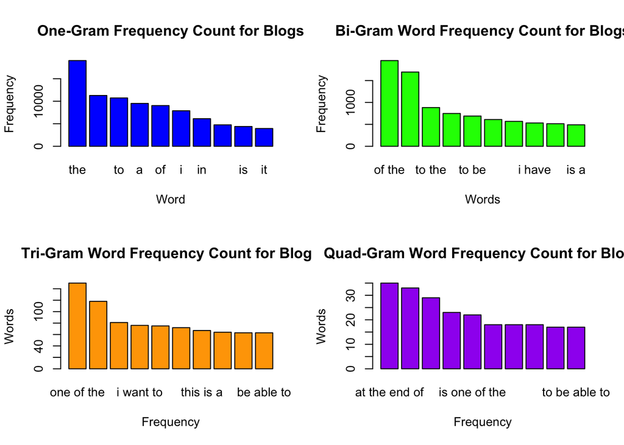

## Next Steps and plan for prediction alogrithm and Shiny App

The user will enter text input into the application. Once the spacebar or submit button is clicked the application will recommend words. The 2-gram,3-gram and 4-gram dataset will be returned from the processed. The n-gram dataset will be used to predict the next word.